# Data Mining Versuch Verkehrsschilderkennung mit Neuronalen Netzen

- **Studierende**: Paul Michels (pm080), Erzan Gashi (eg053), Patryk Gadziomski (pg058)
- **Autor:** Prof. Dr. Johannes Maucher
- **Datum:** 01.06.2021

## Abgabe:

- **Abzugeben ist das Jupyter Notebook mit dem verlangten Implementierungen und den entsprechenden Ausgaben.**
- **Das Notebook ist als .ipynb und als .html abzugeben.**
- **Klausurelevante Fragen sind Dokument "Fragenkatalog Datamining" zu finden.**
- Antworten auf Fragen im Notebook, Diskussionen und Beschreibung der Ergebnisse sind optional (aber empfohlen) und werden nicht bewertet.
- [Übersicht Data Mining Praktikum](https://maucher.pages.mi.hdm-stuttgart.de/ai/page/dm/)

# Einführung

In diesem Versuch soll ein Convolutional Neural Network (CNN) für die Erkennung von Verkehrschildern implementiert, trainiert, evaluiert und getestet werden. Als Eingabe erhält das neuronale Netz Bilder von deutschen Verkehrsschildern. Ausgabe ist der Typ des Verkehrsschilds. Für Training und Test sind die Verkehrsschildbilder schon in separate Verzeichnissen abgelegt. Neben den Bildern selbst, enthält das zu diesem Versuch gehörende Datenverzeichnis auch Dateien mit Metadaten, die z.B. Bildeigenschaften, Verkehrsschildbedeutungen und die zugehörigen Klassenlabel beschreiben. Die Daten können Sie von hier herunterladen: https://cloud.mi.hdm-stuttgart.de/s/2mTmkPejeP8s9NL

## Lernziele:

In diesem Versuch sollen Kenntnisse in folgenden Themen vermittelt werden:

- Convolutional Neural Networks (CNNs)
- Implementierung Tiefer Neuronaler Netze mit Tensorflow und Keras:
  - Definition der Netzarchitektur
  - Training
  - Evaluation und Test
- Einfache Methoden der Bildverarbeitung:
  - Augmentierung
  - Kontrastverstärkung
- Evaluation eines Klassifikators

## Vorbereitung

### Grundlagen Neuronale Netze

Machen Sie sich mit den [Grundlagen herkömmlicher Neuronaler Netze (KI Vorlesung)](https://lectures.mi.hdm-stuttgart.de/mi7ai/06NeuralNets.html) und den [Grundlagen Convolutional Neural Networks ((KI Vorlesung))](https://lectures.mi.hdm-stuttgart.de/mi7ai/06ConvolutionNeuralNetworks.html) vertraut (**user**: *mi7ai*, **pw**: *ailecture*).

### Implementierung Neuronaler Netze mit Tensorflow und Keras

Machen Sie sich mit der Implementierung von Neuronalen Netzen mit Tensorflow und Keras vertraut. Z.B. mit den [Tensorflow Quickstart Tutorials](https://www.tensorflow.org/tutorials/quickstart/beginner)

# Durchführung

```python
import tensorflow as tf
import pandas as pd
import numpy as np

import skimage as ski
from skimage.transform import resize
from skimage.exposure import equalize_adapthist

from sklearn.preprocessing import LabelBinarizer
from sklearn.metrics import classification_report

import matplotlib.pyplot as plt
```

## Vorbereitende Untersuchungen

1. Importieren Sie ein Bild aus dem Verzeichnis `Train` mit der [scikit-image.io](https://scikit-image.org/docs/stable/api/skimage.io.html)-Methode `imread()` und zeigen Sie dieses mit der Methode `imshow()` an. Geben Sie die Größe des Bildes aus (Attribut `.shape`).

[figure not shown]

```python
selected_img = ski.io.imread('traffic-sign-recognition\\data\\Train\\0\\00000_00000_00000.png')
plt.imshow(selected_img)
```

```python
selected_img.shape
```

```
(30, 29, 3)
```

2. Verändern Sie die Größe des Bildes mit der [scikit-image.transform](https://scikit-image.org/docs/stable/api/skimage.transform.html)-Methode `resize()` auf eine Größe von $32x32x3$. Die Verzerrung des Seitenverhältnisses kann dabei ignoriert werden. Diese Methode führt auch eine Normalisierung der Pixelwerte von [0,255] auf [0,1] durch.

```python
selected_img = resize(selected_img, (32, 32, 3))
selected_img.shape
```

```
(32, 32, 3)
```

3. Führen Sie mit der [scikit-image.exposure](https://scikit-image.org/docs/stable/api/skimage.exposure.html)-Methode `equalize_adapthist()` eine Kontrastverstärkung des Bildes durch. Zeigen Sie das vergrößerte und kontrastangereicherte Bild an. **Anmerkung:** Das kontrastverstärkte Bild sieht zwar unschöner aus, auf der Basis kontrastverstärkter Bilder läßt sich aber im allgemeinen die Objekterkennung verbessern.

[figure not shown]

```python
selected_img = equalize_adapthist(selected_img)
plt.imshow(selected_img)
```

```python
selected_img.shape
```

```
(32, 32, 3)
```

4. Importieren Sie die Datei `Train.csv` und machen Sie sich mit deren Inhalt vertraut. Die Datei `Test.csv` ist gleich strukturiert, bezieht sich aber auf die Bilder im Verzeichnis `Test`. Wieviele Zeilen enthalten die Dateien?

```python
train_data = pd.read_csv('traffic-sign-recognition\\data\\Train.csv')
train_data.head()
```

|  | Width | Height | Roi.X1 | Roi.Y1 | Roi.X2 | Roi.Y2 | ClassId | Path |
| --- | --- | --- | --- | --- | --- | --- | --- | --- |
| 0 | 27 | 26 | 5 | 5 | 22 | 20 | 20 | Train/20/00020_00000_00000.png |
| 1 | 28 | 27 | 5 | 6 | 23 | 22 | 20 | Train/20/00020_00000_00001.png |
| 2 | 29 | 26 | 6 | 5 | 24 | 21 | 20 | Train/20/00020_00000_00002.png |
| 3 | 28 | 27 | 5 | 6 | 23 | 22 | 20 | Train/20/00020_00000_00003.png |
| 4 | 28 | 26 | 5 | 5 | 23 | 21 | 20 | Train/20/00020_00000_00004.png |

```python
print(f'Die Train.csv enthält {train_data.shape[0]} Zeilen')
```

```
Die Train.csv enthält 39209 Zeilen
```

```python
test_data = pd.read_csv('traffic-sign-recognition\\data\\Test.csv')
test_data.head()
```

|  | Width | Height | Roi.X1 | Roi.Y1 | Roi.X2 | Roi.Y2 | ClassId | Path |
| --- | --- | --- | --- | --- | --- | --- | --- | --- |
| 0 | 53 | 54 | 6 | 5 | 48 | 49 | 16 | Test/00000.png |
| 1 | 42 | 45 | 5 | 5 | 36 | 40 | 1 | Test/00001.png |
| 2 | 48 | 52 | 6 | 6 | 43 | 47 | 38 | Test/00002.png |
| 3 | 27 | 29 | 5 | 5 | 22 | 24 | 33 | Test/00003.png |
| 4 | 60 | 57 | 5 | 5 | 55 | 52 | 11 | Test/00004.png |

```python
print(f'Die Test.csv enthält {test_data.shape[0]} Zeilen')
```

```
Die Test.csv enthält 12630 Zeilen
```

5. Importieren Sie die Datei `signnames.csv` und machen Sie sich mit deren Inhalt vertraut.

```python
signnames = pd.read_csv('traffic-sign-recognition\\data\\signnames.csv')
signnames.head()
```

|  | ClassId | SignName |
| --- | --- | --- |
| 0 | 0 | Speed limit (20km/h) |
| 1 | 1 | Speed limit (30km/h) |
| 2 | 2 | Speed limit (50km/h) |
| 3 | 3 | Speed limit (60km/h) |
| 4 | 4 | Speed limit (70km/h) |

## Funktion für den Import aller Trainings- bzw. Testbilder

Schreiben Sie eine Funktion mit folgenden Eigenschaften:

- Der Funktion wird der Name der Datei übergeben, in welcher die Metadaten stehen, also entweder `Train.csv` oder `Test.csv`.
- Rückgabewerte der Funktion sind
  - ein 4-dimensionales numpy-array, das alle Bilder des jeweiligen Verzeichnisses (Training oder Test) enthält.
  - ein 1-dimensionales numpy-array, das die Klassenlabel aller Bilder enthält.
- Die Bilder müssen alle auf eine Größe von $32x32x3$ skaliert werden (wie in der Vorbereitungsaufgabe).
- Für alle Bilder ist eine Kontrastverstärkung durchzuführen (wie in der Vorbereitungsaufgabe).

**Tipps für die Implementierung dieser Funktion:**

Iterieren Sie mit einer for-Schleife über alle Zeilen des metadaten-Files. Pro Iteration kann dann

- der vollständige Verzeichnis- und Filenamen ausgelesen werden,
- das entsprechende Bild mit `imread()` eingelesen werden,
- das Bild auf die vorgegebene Größe angepasst werden,
- der Kontrast des Bildes verstärkt werden.

**Wichtig:** In den von der Funktion zurückgegebenen Arrays, dürfen die Bilder nicht wie in der ursprünglichen Reihenfolge im Dateiverzeichnis enthalten sein. Um sicherzustellen, dass beim Training jedes Minibatch möglichst viele verschiedene Klassen enthält, muss die Reihenfolge geshuffelt werden. Am einfachsten ist es, wenn gleich die Zeilen des Metadatenfiles geshuffelt werden.

```python
def import_file(file_name):
    file_path = f'traffic-sign-recognition\\data\\{file_name}.csv'
    data = pd.read_csv(file_path)
    data = data.sample(frac=1.0, random_state=42).reset_index(drop=True)

    imgs_number = data.shape[0]
    images = np.zeros((imgs_number, 32, 32, 3), dtype=np.float32)
    labels = np.zeros(imgs_number, dtype=np.float32)

    for index, row in data.iterrows():
        img = ski.io.imread(f'traffic-sign-recognition\\data\\{row["Path"]}')
        img = resize(img, (32, 32, 3))
        img = equalize_adapthist(img)

        images[index] = img
        labels[index] = row['ClassId']

    return images, labels
```

## Laden und Vorverarbeiten der Trainings- und Testdaten

1. Laden Sie mit der in der vorigen Teilaufgabe implementierten Funktion alle Trainingsbilder (`trainX`), Trainingslabel (`trainY`), Testbilder (`testX`) und Testlabel (`testY`)

```python
trainX, trainY = import_file('Train')
```

```python
trainX.shape, trainY.shape
```

```
((39209, 32, 32, 3), (39209,))
```

```python
testX, testY = import_file('Test')
```

```python
testX.shape, testY.shape
```

```
((12630, 32, 32, 3), (12630,))
```

2. Bestimmen Sie die Häufigkeitsverteilung der Klassen in den Trainings- und Testdaten. Visualisieren Sie diese.

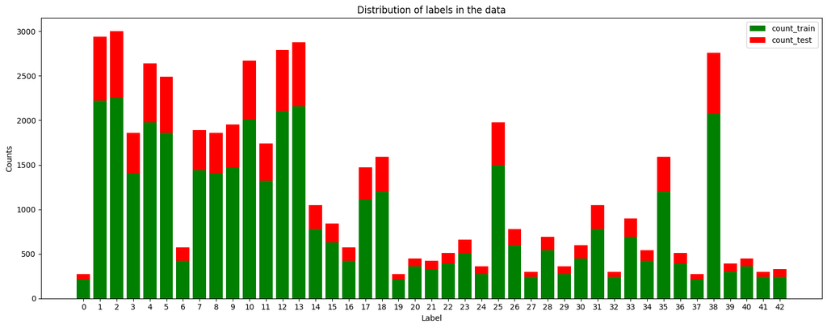

```python
labels_train, l_count_train = np.unique(trainY, return_counts=True)
labels_test, l_count_test = np.unique(testY, return_counts=True)

df = pd.DataFrame({'label': labels_train, 'count_train': l_count_train, 'count_test': l_count_test})

# Create the stacked bar plot
plt.figure(figsize=(15, 6))
plt.bar(df['label'], df['count_train'], label='count_train', color='green')
plt.bar(df['label'], df['count_test'], bottom=df['count_train'], label='count_test', color='red')

# Customize the plot
plt.xlabel('Label')
plt.ylabel('Counts')
plt.title('Distribution of labels in the data')
plt.legend()
plt.xticks(df['label'])
plt.tight_layout()

# Show the plot
plt.show()
```

3. Alle Labels, sowohl der Trainings- als auch der Testdaten müssen One-Hot-encodiert werden.

```python
lb = LabelBinarizer()
```

```python
lb.fit(trainY)
trainY_ohe = lb.transform(trainY)
```

```python
lb.fit(testY)
testY_ohe = lb.transform(testY)
```

## Definition der CNN Architektur

Schreiben Sie eine Funktion `generateCNN(width, height, depth, classes)` die eine Keras CNN-Architektur zurück gibt. Für die Definition der Architektur werden dieser Funktion die Parameter:

- `width`: Breite der Bilder
- `height`: Höhe der Bilder
- `depth`: Anzahl der Kanäle pro Bild
- `classes`: Anzahl der unterschiedlichen Klassen

übergeben. Die in der Funktion zu implementierende Architektur ist im folgenden Bild dargestellt. In der Spalte *Output shape* bezeichnen die zweite und dritte Zahl die Breite und die Höhe der einzelnen Kanäle (*Bilder*), der letzte Parameter bezeichnet die Anzahl der Kanäle (Parameter *filters* in der Konfiguration). In der Übersichtstabelle ist die Filtergröße nicht aufgeführt. Empfohlen sind folgende Größen:

- für alle Pooling Layer: *pool_size=(2,2)*.
- für den ersten Conv2D-Layer: *kernel_size=(5,5)*.
- für alle weiteren Conv2D-Layer: *kernel_size=(3,3)*

**Anmerkung:** Der in der Tabelle mit *flatten_5* bezeichnete Layer ist nicht notwendig und erzeugt in bestimmten Keras-Versionen eine Fehlermeldung. Der Layer sollte nicht in die Architektur mit aufgenommen werden.

[figure not shown]

```python
def generateCNN(width, height, depth, classes):

    model = tf.keras.models.Sequential([
        tf.keras.layers.Conv2D(filters=8, kernel_size=(5, 5), input_shape=(width, height, depth), padding='same'),
        tf.keras.layers.Activation(activation='relu'),
        tf.keras.layers.BatchNormalization(),
        tf.keras.layers.MaxPooling2D(pool_size=(2, 2)),

        tf.keras.layers.Conv2D(filters=16, kernel_size=(3, 3), padding='same'),
        tf.keras.layers.Activation(activation='relu'),
        tf.keras.layers.BatchNormalization(),

        tf.keras.layers.Conv2D(filters=16, kernel_size=(3, 3), padding='same'),
        tf.keras.layers.Activation(activation='relu'),
        tf.keras.layers.BatchNormalization(),
        tf.keras.layers.MaxPooling2D(pool_size=(2, 2)),

        tf.keras.layers.Conv2D(filters=32, kernel_size=(3, 3), padding='same'),
        tf.keras.layers.Activation(activation='relu'),
        tf.keras.layers.BatchNormalization(),

        tf.keras.layers.Conv2D(filters=32, kernel_size=(3, 3), padding='same'),
        tf.keras.layers.Activation(activation='relu'),
        tf.keras.layers.MaxPooling2D(pool_size=(2, 2)),

        tf.keras.layers.Flatten(),

        tf.keras.layers.Dense(units=128),
        tf.keras.layers.Activation(activation='relu'),

        tf.keras.layers.BatchNormalization(),
        tf.keras.layers.Dropout(rate=0.2),

        tf.keras.layers.Dense(units=128),
        tf.keras.layers.Activation(activation='relu'),

        tf.keras.layers.BatchNormalization(),
        tf.keras.layers.Dropout(0.2),

        tf.keras.layers.Dense(units=classes),
        tf.keras.layers.Activation(activation='softmax')
        ])

    return model
```

## Training des CNN

Rufen Sie die im vorigen Abschnitt implementierte Funktion `generateCNN()` auf und weisen Sie die von der Funktion zurückgegebene Architektur der Variablen `model` zu. Durch Aufruf der Funktion `model.summary()` erhalten Sie eine Übersicht des erzeugten Netzes.

Für das Training soll der `Adam`-Algorithmus aus dem Modul `tensorflow.keras.optimizers` benutzt werden. `Adam` implementiert ein *Stochastic Gradient Descent*-Lernverfahren, welches die Lernraten für die Gewichte individuell und dynamisch anpasst.

In den folgenden zwei Codezellen, werden die Trainingsparameter konfiguriert:

```python
model = generateCNN(32, 32, 3, 43)
```

```python
model.summary()
```

```
Model: "sequential"
```

```
┏━━━━━━━━━━━━━━━━━━━━━━━━━━━━━━━━━┳━━━━━━━━━━━━━━━━━━━━━━━━┳━━━━━━━━━━━━━━━┓
┃ Layer (type)                    ┃ Output Shape           ┃       Param # ┃
┡━━━━━━━━━━━━━━━━━━━━━━━━━━━━━━━━━╇━━━━━━━━━━━━━━━━━━━━━━━━╇━━━━━━━━━━━━━━━┩
│ conv2d (Conv2D)                 │ (None, 32, 32, 8)      │           608 │
├─────────────────────────────────┼────────────────────────┼───────────────┤
│ activation (Activation)         │ (None, 32, 32, 8)      │             0 │
├─────────────────────────────────┼────────────────────────┼───────────────┤
│ batch_normalization             │ (None, 32, 32, 8)      │            32 │
│ (BatchNormalization)            │                        │               │
├─────────────────────────────────┼────────────────────────┼───────────────┤
│ max_pooling2d (MaxPooling2D)    │ (None, 16, 16, 8)      │             0 │
├─────────────────────────────────┼────────────────────────┼───────────────┤
│ conv2d_1 (Conv2D)               │ (None, 16, 16, 16)     │         1,168 │
├─────────────────────────────────┼────────────────────────┼───────────────┤
│ activation_1 (Activation)       │ (None, 16, 16, 16)     │             0 │
├─────────────────────────────────┼────────────────────────┼───────────────┤
│ batch_normalization_1           │ (None, 16, 16, 16)     │            64 │
│ (BatchNormalization)            │                        │               │
├─────────────────────────────────┼────────────────────────┼───────────────┤
│ conv2d_2 (Conv2D)               │ (None, 16, 16, 16)     │         2,320 │
├─────────────────────────────────┼────────────────────────┼───────────────┤
│ activation_2 (Activation)       │ (None, 16, 16, 16)     │             0 │
├─────────────────────────────────┼────────────────────────┼───────────────┤
│ batch_normalization_2           │ (None, 16, 16, 16)     │            64 │
│ (BatchNormalization)            │                        │               │
├─────────────────────────────────┼────────────────────────┼───────────────┤
│ max_pooling2d_1 (MaxPooling2D)  │ (None, 8, 8, 16)       │             0 │
├─────────────────────────────────┼────────────────────────┼───────────────┤
│ conv2d_3 (Conv2D)               │ (None, 8, 8, 32)       │         4,640 │
├─────────────────────────────────┼────────────────────────┼───────────────┤
│ activation_3 (Activation)       │ (None, 8, 8, 32)       │             0 │
├─────────────────────────────────┼────────────────────────┼───────────────┤
│ batch_normalization_3           │ (None, 8, 8, 32)       │           128 │
│ (BatchNormalization)            │                        │               │
├─────────────────────────────────┼────────────────────────┼───────────────┤
│ conv2d_4 (Conv2D)               │ (None, 8, 8, 32)       │         9,248 │
├─────────────────────────────────┼────────────────────────┼───────────────┤
│ activation_4 (Activation)       │ (None, 8, 8, 32)       │             0 │
├─────────────────────────────────┼────────────────────────┼───────────────┤
│ max_pooling2d_2 (MaxPooling2D)  │ (None, 4, 4, 32)       │             0 │
```

[output cut: 10 more lines]

```
│ dropout (Dropout)               │ (None, 128)            │             0 │
├─────────────────────────────────┼────────────────────────┼───────────────┤
│ dense_1 (Dense)                 │ (None, 128)            │        16,512 │
├─────────────────────────────────┼────────────────────────┼───────────────┤
│ activation_6 (Activation)       │ (None, 128)            │             0 │
├─────────────────────────────────┼────────────────────────┼───────────────┤
│ batch_normalization_5           │ (None, 128)            │           512 │
│ (BatchNormalization)            │                        │               │
├─────────────────────────────────┼────────────────────────┼───────────────┤
│ dropout_1 (Dropout)             │ (None, 128)            │             0 │
├─────────────────────────────────┼────────────────────────┼───────────────┤
│ dense_2 (Dense)                 │ (None, 43)             │         5,547 │
├─────────────────────────────────┼────────────────────────┼───────────────┤
│ activation_7 (Activation)       │ (None, 43)             │             0 │
└─────────────────────────────────┴────────────────────────┴───────────────┘
```

```
 Total params: 107,019 (418.04 KB)
```

```
 Trainable params: 106,363 (415.48 KB)
```

```
 Non-trainable params: 656 (2.56 KB)
```

```python
NUM_EPOCHS = 15 # Number of training epochs
INIT_LR = 1e-3 # Initial Learning Rate for ADAM training
BS = 64 # Size of minibatches
```

```python
opt = tf.keras.optimizers.Adam(learning_rate=INIT_LR) # rename lr to learning_rate
model.compile(loss="categorical_crossentropy", optimizer=opt, metrics=["accuracy"])
```

Für das Training sollen nicht nur die vorhandenen Trainingsbilder eingesetzt werden, sondern zusätzlich Bilder die Augmentierungen der Trainingsbilder sind. Augmentierte Bilder können mit dem `ImageDataGenerator` des Moduls `tensorflow.keras.preprocessing.image` erzeugt werden. Der Code für die Erzeugung des in diesem Projekt eingesetzten Objekts ist unten gegeben.

**Aufgabe:** Erklären Sie was in dieser Codezelle definiert wird.

```python
# construct the image generator for data augmentation
aug = tf.keras.preprocessing.image.ImageDataGenerator(
    rotation_range=10,
    zoom_range=0.15,
    width_shift_range=0.1,
    height_shift_range=0.1,
    shear_range=0.15,
    horizontal_flip=False,
    vertical_flip=False,
    fill_mode="nearest")
```

1. `rotation_range`: Das Bild wird zufällig um 10 Grad gedreht
2. `zoom_range`: Das Bild wird zufällig um bis zu 15% vergrößert oder verkleinert
3. `width_shift_range`: Das Bild wird um bis zu 10% in seiner Breite verschoben
4. `height_shift_range`: Das Bild wird um bis zu 10% in seiner Höhe verschoben
5. `shear_range`: Das Bild wird mit maximal 15 Grad verzerrt
6. `horizontal_flip`: Das Bild wird nicht horizontal geflippt
7. `vertical_flip`: Das Bild wird nicht vertikal geflippt
8. `fill_mode`: Auffüllung der leeren Bereich nach Transformation = die nächsten Pixel

Das Training wird mit folgender Codezelle ausgeführt.

**Aufgabe:** Erklären Sie die Argumente der Funktion `fit()`.

Für die Ausführung der Zelle muss das Dictionary `classWeight` angelegt sein. Dieses enthält für jede Klasse den Klassenindex als key und den relativen Anteil dieser Klasse in den Trainingsbildern als Value. Wenn z.B. 30% aller Trainingsdaten zur Klasse 0 gehören, dann wäre der Value zum Key 0 der Wert 0.3.

1. `aug` ist der zuvor definierte `ImageDataGenrator` für Datenaugmentation. Der `flow`-Befehl stellt sicher, dass die Daten in Batches geladen werden und gleichzeitig die Datenaugmentation angewedent wird. `trainX` sind die Trainingsdaten und `trainY` die zugehörigen Labels. `BS` ist die oben definierte Batchgröße.
2. Die Testdaten und Testlabels werden in `validation_data` verwendet, um die Leistung des Modells auf den Testdaten zu bewerten.
3. Bei `steps_per_epoch` wird die Anzahl der Schritte (Batches) pro Epoche definiert. Dabei ist `trainX.shape[0]` die Anzahl der Trainingsbeispiele und `BS` die Batchgröße.
4. `epochs` gibt mit `NUM_EPOCHS` die Anzahl der Epochen an, also wie of das Modell die gesamten Trainigsdaten durchlaufen soll.
5. `class_weight` stellt mit `classWeight` ein Dictionarie dar, welcher die Gewichte für jede Klasse aufweist.
6. `verbose` ist zuständig für die Informationsanzeige. Mit `1` wird der Fortschritt des Trainings angezeigt, mit der Epochennummer, Verlustfunktion und der Metriken.

```python
labels_train, l_count_train = np.unique(trainY, return_counts=True)

classWeight_df = pd.DataFrame({'count_train': l_count_train/sum(l_count_train)})

classWeight = classWeight_df.to_dict()['count_train']
```

```python
# compile the model and train the network
print("[INFO] training network...")
H = model.fit(
    aug.flow(trainX, trainY_ohe, batch_size=BS),
    validation_data=(testX, testY_ohe),
    steps_per_epoch=trainX.shape[0] // BS,
    epochs=NUM_EPOCHS,
    class_weight=classWeight,
    verbose=1)
```

```
[INFO] training network...
```

```
612/612 ━━━━━━━━━━━━━━━━━━━━ 48s 72ms/step - accuracy: 0.3260 - loss: 0.0812 - val_accuracy: 0.5622 - val_loss: 1.4892
  1/612 ━━━━━━━━━━━━━━━━━━━━ 18s 30ms/step - accuracy: 0.6250 - loss: 0.0245
```

```
612/612 ━━━━━━━━━━━━━━━━━━━━ 2s 3ms/step - accuracy: 0.6250 - loss: 0.0245 - val_accuracy: 0.5487 - val_loss: 1.5467
612/612 ━━━━━━━━━━━━━━━━━━━━ 48s 78ms/step - accuracy: 0.7035 - loss: 0.0219 - val_accuracy: 0.7150 - val_loss: 0.9282
612/612 ━━━━━━━━━━━━━━━━━━━━ 3s 4ms/step - accuracy: 0.7500 - loss: 0.0176 - val_accuracy: 0.7246 - val_loss: 0.8865
612/612 ━━━━━━━━━━━━━━━━━━━━ 51s 84ms/step - accuracy: 0.8065 - loss: 0.0127 - val_accuracy: 0.8629 - val_loss: 0.4105
612/612 ━━━━━━━━━━━━━━━━━━━━ 4s 6ms/step - accuracy: 0.8906 - loss: 0.0084 - val_accuracy: 0.8629 - val_loss: 0.4132
612/612 ━━━━━━━━━━━━━━━━━━━━ 55s 89ms/step - accuracy: 0.8576 - loss: 0.0090 - val_accuracy: 0.8760 - val_loss: 0.3858
612/612 ━━━━━━━━━━━━━━━━━━━━ 3s 5ms/step - accuracy: 0.8281 - loss: 0.0109 - val_accuracy: 0.8788 - val_loss: 0.3722
612/612 ━━━━━━━━━━━━━━━━━━━━ 45s 73ms/step - accuracy: 0.8843 - loss: 0.0073 - val_accuracy: 0.9119 - val_loss: 0.2825
612/612 ━━━━━━━━━━━━━━━━━━━━ 2s 3ms/step - accuracy: 0.9219 - loss: 0.0028 - val_accuracy: 0.9096 - val_loss: 0.2893
612/612 ━━━━━━━━━━━━━━━━━━━━ 40s 66ms/step - accuracy: 0.9010 - loss: 0.0062 - val_accuracy: 0.9120 - val_loss: 0.2708
612/612 ━━━━━━━━━━━━━━━━━━━━ 2s 3ms/step - accuracy: 0.8594 - loss: 0.0134 - val_accuracy: 0.9144 - val_loss: 0.2650
612/612 ━━━━━━━━━━━━━━━━━━━━ 39s 64ms/step - accuracy: 0.9155 - loss: 0.0053 - val_accuracy: 0.9108 - val_loss: 0.2830
612/612 ━━━━━━━━━━━━━━━━━━━━ 2s 3ms/step - accuracy: 0.8750 - loss: 0.0033 - val_accuracy: 0.9079 - val_loss: 0.2947
612/612 ━━━━━━━━━━━━━━━━━━━━ 41s 67ms/step - accuracy: 0.9255 - loss: 0.0045 - val_accuracy: 0.9215 - val_loss: 0.2501
```

Visualisieren Sie die Entwicklung der *Accuracy* über dem Fortschritt der Trainingsepochen. Plotten Sie dabei die entsprechenden Kurven der Accuracy auf den Trainings- und auf den Testdaten in einen Graphen.

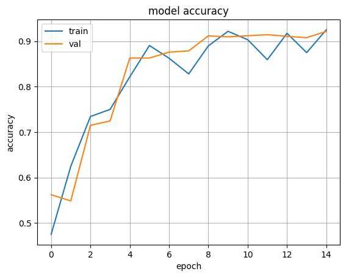

```python
plt.plot(H.history['accuracy'])
plt.plot(H.history['val_accuracy'])
plt.title('model accuracy')
plt.ylabel('accuracy')
plt.xlabel('epoch')
plt.legend(['train', 'val'], loc='upper left')
plt.grid(True)
plt.show()
```

## Evaluation des gelernten Modells

Wenden Sie das gelernte CNN an, um für alle Bilder des Testdatensatzes die Art des Verkehrsschildes zu bestimmen. Evaluieren Sie die Qualität des CNN indem Sie einen `classification_report()` aus dem Modul `sklearn.metrics` erzeugen.

```python
predictions = model.predict(testX)
predictions_labels = [np.argmax(predictions[index]) for index, i in enumerate(predictions)]
```

```
395/395 ━━━━━━━━━━━━━━━━━━━━ 2s 5ms/step
```

```python
print(classification_report(testY, predictions_labels))
```

```
              precision    recall  f1-score   support

         0.0       1.00      0.22      0.36        60
         1.0       0.87      1.00      0.93       720
         2.0       0.96      0.98      0.97       750
         3.0       0.97      0.86      0.91       450
         4.0       0.98      0.94      0.96       660
         5.0       0.81      0.96      0.88       630
         6.0       0.67      0.97      0.79       150
         7.0       0.92      0.94      0.93       450
         8.0       0.98      0.88      0.93       450
         9.0       0.96      0.99      0.97       480
        10.0       1.00      0.93      0.97       660
        11.0       0.88      0.96      0.92       420
        12.0       0.99      0.99      0.99       690
        13.0       0.96      1.00      0.98       720
        14.0       1.00      0.92      0.96       270
        15.0       0.99      0.88      0.93       210
        16.0       0.99      0.91      0.95       150
        17.0       0.96      0.91      0.93       360
        18.0       0.99      0.66      0.79       390
        19.0       0.86      0.70      0.77        60
        20.0       0.84      0.90      0.87        90
        21.0       0.73      0.58      0.65        90
        22.0       0.96      0.78      0.86       120
        23.0       0.74      0.89      0.81       150
        24.0       0.99      0.91      0.95        90
        25.0       0.85      0.99      0.91       480
        26.0       0.65      0.84      0.73       180
        27.0       0.86      0.85      0.86        60
        28.0       0.86      0.93      0.89       150
        29.0       0.87      0.59      0.70        90
        30.0       0.85      0.57      0.69       150
        31.0       0.89      0.97      0.93       270
        32.0       0.95      0.65      0.77        60
        33.0       0.97      0.98      0.97       210
        34.0       1.00      0.94      0.97       120
        35.0       0.93      0.99      0.96       390
        36.0       0.94      0.97      0.95       120
        37.0       0.68      0.68      0.68        60
        38.0       0.97      1.00      0.98       690
        39.0       0.92      0.92      0.92        90
        40.0       0.85      0.71      0.78        90
        41.0       0.96      0.92      0.94        60
        42.0       0.92      0.54      0.69        90

    accuracy                           0.92     12630
   macro avg       0.91      0.85      0.87     12630
weighted avg       0.93      0.92      0.92     12630
```

1. Welche Metriken werden im Report angezeigt? Beschreiben Sie diese kurz?

Classification Report

- Ein classification Report enthält die folgenden Metriken für jede Klasse: Precision, Recall, F1-Score und Support

Intepretation:

- Precision:
  - Niedrige Precision in einer Klasse weist auf viele False Positives hin
- Recall:
  - Ein niedriger Recall zeigt, dass der Klassifikation viele tatsächlichen Instanzen der Klasse nicht erkennt
- F1-Score:
  - Diese Metrik ist wichtig, wenn Precision und Recall für eie Klasse stark variieren
- Accuracy:
  - Gibt den Anteil der korrekt klassifizierten Datenpunkten an allen Datenpunkten an
  - 100% = Alle Datenpunkte wurden richtig erkannt
- Macro avg:
  - Summe der einzelnen Metriken geteilt durch die Anzahl der Klassen (Arithmetisches Mittel)
- Weighted avg:
  - Summe der einzelnen Metriken multipliziert mit dem jeweiligen Support der Klassen, geteilt durch die gesamt Anzahl der Testdaten.$$ \sum_{k = 0}^{n} x_k * (\frac{support}{totalSupport}) $$

n = Anzahl der Klassen

$x_k$ = Wert der Metrik der k-ten Klasse

2. Diskutieren Sie die Klassifikationsgenauigkeit des CNN anhand des Reports.

Die Genauigkeit des Modells liegt bei ca. 90% (± 5%, je nach Trainingsablauf), damit ist das Modell recht zuverlässig. Precision und Recall sind bei weighted Average nah aneinander, was bedeuted dass das Modell gut angepasst ist. Der weighted Average ist aussagekräftiger als der Macro Average, da er die Verteilung der Klassen in den Testdaten berücksichtigt. In der echten Welt kommen Schilder unterschiedlich oft vor, weshalb die Berücksichtigung der Heufigkeit der Schilder relevant ist.

Zeigen Sie 5 Bilder an, die nicht korrekt klassifiziert wurden. Läßt sich die Fehlklassifikation erklären?

```python
false_pred = []

for img, pred, y in zip(testX, predictions_labels, testY):
    if pred != y:
        false_pred.append((signnames[signnames['ClassId'] == pred].iloc[0]['SignName'],
                           img,
                           signnames[signnames['ClassId'] == y].iloc[0]['SignName']))
```

```
Speed limit (100km/h)
No passing for vehicles over 3.5 metric tons
```

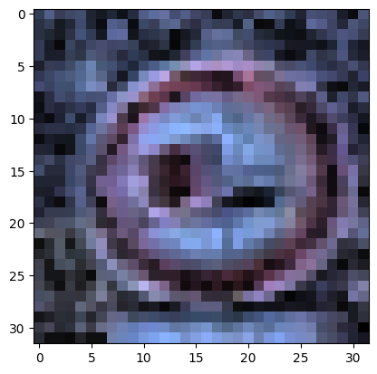

```python
print(false_pred[0][0])
print(false_pred[0][2])
plt.imshow(false_pred[0][1])
```

```
No passing
Vehicles over 3.5 metric tons prohibited
```

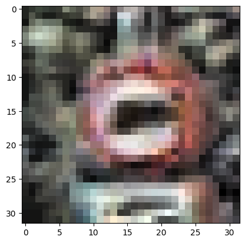

```python
print(false_pred[1][0])
print(false_pred[1][2])
plt.imshow(false_pred[1][1])
```

```
Slippery road
Beware of ice/snow
```

[figure not shown]

```python
print(false_pred[2][0])
print(false_pred[2][2])
plt.imshow(false_pred[2][1])
```

```
Speed limit (80km/h)
No passing for vehicles over 3.5 metric tons
```

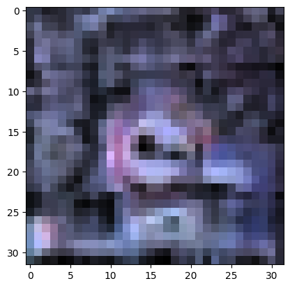

```python
print(false_pred[3][0])
print(false_pred[3][2])
plt.imshow(false_pred[3][1])
```

```
Speed limit (60km/h)
Speed limit (120km/h)
```

[figure not shown]

```python
print(false_pred[4][0])
print(false_pred[4][2])
plt.imshow(false_pred[4][1])
```

# Hypothese: Die Erhöhung der Epochen beim Training des CNNs, steigert die Accuracy des Modells, da das Modell mehr Epochen hat um die verfügbaren Merkmale zu lernen.

## Training der Modelle

```python
epochs_to_try = [8, 15, 30, 60]
INIT_LR = 1e-3
BS = 64
```

```python
def train_CNN(epochs, lr, bs, class_weigths):
    history_per_epoch = {}

    for epochs in epochs_to_try:
        print(f"Training with {epochs} epochs...")
        model = generateCNN(32, 32, 3, 43)
        opt = tf.keras.optimizers.Adam(learning_rate=lr)
        model.compile(loss="categorical_crossentropy", optimizer=opt, metrics=["accuracy"])

        aug = tf.keras.preprocessing.image.ImageDataGenerator(
            rotation_range=10,
            zoom_range=0.15,
            width_shift_range=0.1,
            height_shift_range=0.1,
            shear_range=0.15,
            horizontal_flip=False,
            vertical_flip=False,
            fill_mode="nearest")

        history = model.fit(
            aug.flow(trainX, trainY_ohe, batch_size=bs),
            validation_data=(testX, testY_ohe),
            steps_per_epoch=trainX.shape[0] // bs,
            epochs=epochs,
            class_weight=class_weigths,
            verbose=1)

        history_per_epoch[epochs] = history

    return history_per_epoch
```

```python
history = train_CNN(epochs_to_try, INIT_LR, BS, classWeight)
```

```
Training with 8 epochs...
```

```
612/612 ━━━━━━━━━━━━━━━━━━━━ 45s 68ms/step - accuracy: 0.3286 - loss: 0.0800 - val_accuracy: 0.7191 - val_loss: 0.9282
  1/612 ━━━━━━━━━━━━━━━━━━━━ 26s 43ms/step - accuracy: 0.6250 - loss: 0.0251
```

```
612/612 ━━━━━━━━━━━━━━━━━━━━ 2s 3ms/step - accuracy: 0.6250 - loss: 0.0251 - val_accuracy: 0.7177 - val_loss: 0.9347
612/612 ━━━━━━━━━━━━━━━━━━━━ 126s 206ms/step - accuracy: 0.7067 - loss: 0.0218 - val_accuracy: 0.7758 - val_loss: 0.7225
612/612 ━━━━━━━━━━━━━━━━━━━━ 6s 9ms/step - accuracy: 0.7969 - loss: 0.0131 - val_accuracy: 0.7721 - val_loss: 0.7321
612/612 ━━━━━━━━━━━━━━━━━━━━ 94s 153ms/step - accuracy: 0.8141 - loss: 0.0124 - val_accuracy: 0.8671 - val_loss: 0.4330
612/612 ━━━━━━━━━━━━━━━━━━━━ 6s 10ms/step - accuracy: 0.8438 - loss: 0.0091 - val_accuracy: 0.8644 - val_loss: 0.4500
612/612 ━━━━━━━━━━━━━━━━━━━━ 69s 113ms/step - accuracy: 0.8647 - loss: 0.0086 - val_accuracy: 0.8736 - val_loss: 0.4060
612/612 ━━━━━━━━━━━━━━━━━━━━ 2s 4ms/step - accuracy: 0.8906 - loss: 0.0039 - val_accuracy: 0.8721 - val_loss: 0.4093
Training with 15 epochs...
612/612 ━━━━━━━━━━━━━━━━━━━━ 94s 147ms/step - accuracy: 0.3153 - loss: 0.0833 - val_accuracy: 0.7063 - val_loss: 0.9361
612/612 ━━━━━━━━━━━━━━━━━━━━ 3s 6ms/step - accuracy: 0.6562 - loss: 0.0288 - val_accuracy: 0.7057 - val_loss: 0.9349
612/612 ━━━━━━━━━━━━━━━━━━━━ 58s 95ms/step - accuracy: 0.6859 - loss: 0.0236 - val_accuracy: 0.7785 - val_loss: 0.6904
612/612 ━━━━━━━━━━━━━━━━━━━━ 2s 4ms/step - accuracy: 0.8438 - loss: 0.0092 - val_accuracy: 0.7787 - val_loss: 0.6933
612/612 ━━━━━━━━━━━━━━━━━━━━ 50s 81ms/step - accuracy: 0.7900 - loss: 0.0141 - val_accuracy: 0.8610 - val_loss: 0.4190
612/612 ━━━━━━━━━━━━━━━━━━━━ 2s 3ms/step - accuracy: 0.8594 - loss: 0.0082 - val_accuracy: 0.8594 - val_loss: 0.4237
612/612 ━━━━━━━━━━━━━━━━━━━━ 49s 79ms/step - accuracy: 0.8400 - loss: 0.0103 - val_accuracy: 0.8112 - val_loss: 0.6715
612/612 ━━━━━━━━━━━━━━━━━━━━ 2s 4ms/step - accuracy: 0.7344 - loss: 0.0162 - val_accuracy: 0.8208 - val_loss: 0.6315
612/612 ━━━━━━━━━━━━━━━━━━━━ 51s 84ms/step - accuracy: 0.8710 - loss: 0.0081 - val_accuracy: 0.8906 - val_loss: 0.3466
612/612 ━━━━━━━━━━━━━━━━━━━━ 2s 4ms/step - accuracy: 0.9219 - loss: 0.0034 - val_accuracy: 0.8921 - val_loss: 0.3423
612/612 ━━━━━━━━━━━━━━━━━━━━ 48s 79ms/step - accuracy: 0.8896 - loss: 0.0069 - val_accuracy: 0.9112 - val_loss: 0.2725
612/612 ━━━━━━━━━━━━━━━━━━━━ 2s 4ms/step - accuracy: 0.9375 - loss: 0.0029 - val_accuracy: 0.9121 - val_loss: 0.2698
612/612 ━━━━━━━━━━━━━━━━━━━━ 48s 78ms/step - accuracy: 0.9040 - loss: 0.0060 - val_accuracy: 0.8082 - val_loss: 0.6864
612/612 ━━━━━━━━━━━━━━━━━━━━ 2s 4ms/step - accuracy: 0.8906 - loss: 0.0135 - val_accuracy: 0.8044 - val_loss: 0.6988
612/612 ━━━━━━━━━━━━━━━━━━━━ 51s 83ms/step - accuracy: 0.9134 - loss: 0.0053 - val_accuracy: 0.9130 - val_loss: 0.2871
Training with 30 epochs...
612/612 ━━━━━━━━━━━━━━━━━━━━ 58s 87ms/step - accuracy: 0.3207 - loss: 0.0831 - val_accuracy: 0.7024 - val_loss: 0.9240
612/612 ━━━━━━━━━━━━━━━━━━━━ 2s 4ms/step - accuracy: 0.5938 - loss: 0.0328 - val_accuracy: 0.7048 - val_loss: 0.9212
612/612 ━━━━━━━━━━━━━━━━━━━━ 50s 82ms/step - accuracy: 0.7012 - loss: 0.0224 - val_accuracy: 0.8045 - val_loss: 0.5977
612/612 ━━━━━━━━━━━━━━━━━━━━ 2s 4ms/step - accuracy: 0.8594 - loss: 0.0079 - val_accuracy: 0.8041 - val_loss: 0.5984
612/612 ━━━━━━━━━━━━━━━━━━━━ 51s 83ms/step - accuracy: 0.8070 - loss: 0.0131 - val_accuracy: 0.8062 - val_loss: 0.6382
612/612 ━━━━━━━━━━━━━━━━━━━━ 2s 4ms/step - accuracy: 0.9062 - loss: 0.0053 - val_accuracy: 0.8081 - val_loss: 0.6246
612/612 ━━━━━━━━━━━━━━━━━━━━ 45s 73ms/step - accuracy: 0.8541 - loss: 0.0094 - val_accuracy: 0.8747 - val_loss: 0.4161
612/612 ━━━━━━━━━━━━━━━━━━━━ 2s 3ms/step - accuracy: 0.9375 - loss: 0.0081 - val_accuracy: 0.8789 - val_loss: 0.3978
612/612 ━━━━━━━━━━━━━━━━━━━━ 44s 72ms/step - accuracy: 0.8801 - loss: 0.0076 - val_accuracy: 0.8638 - val_loss: 0.4398
612/612 ━━━━━━━━━━━━━━━━━━━━ 2s 4ms/step - accuracy: 0.8438 - loss: 0.0095 - val_accuracy: 0.8649 - val_loss: 0.4353
612/612 ━━━━━━━━━━━━━━━━━━━━ 46s 76ms/step - accuracy: 0.8997 - loss: 0.0064 - val_accuracy: 0.8667 - val_loss: 0.4319
612/612 ━━━━━━━━━━━━━━━━━━━━ 2s 4ms/step - accuracy: 0.8906 - loss: 0.0047 - val_accuracy: 0.8697 - val_loss: 0.4177
612/612 ━━━━━━━━━━━━━━━━━━━━ 45s 74ms/step - accuracy: 0.9136 - loss: 0.0054 - val_accuracy: 0.9090 - val_loss: 0.3087
612/612 ━━━━━━━━━━━━━━━━━━━━ 2s 4ms/step - accuracy: 0.9531 - loss: 0.0027 - val_accuracy: 0.9119 - val_loss: 0.3043
612/612 ━━━━━━━━━━━━━━━━━━━━ 45s 74ms/step - accuracy: 0.9226 - loss: 0.0046 - val_accuracy: 0.9061 - val_loss: 0.3238
612/612 ━━━━━━━━━━━━━━━━━━━━ 2s 4ms/step - accuracy: 0.8594 - loss: 0.0118 - val_accuracy: 0.9037 - val_loss: 0.3350
```

[output cut: 60 more lines]

```
612/612 ━━━━━━━━━━━━━━━━━━━━ 2s 4ms/step - accuracy: 0.9688 - loss: 6.7418e-04 - val_accuracy: 0.9435 - val_loss: 0.2072
612/612 ━━━━━━━━━━━━━━━━━━━━ 47s 78ms/step - accuracy: 0.9658 - loss: 0.0021 - val_accuracy: 0.9501 - val_loss: 0.1796
612/612 ━━━━━━━━━━━━━━━━━━━━ 2s 4ms/step - accuracy: 0.9688 - loss: 0.0028 - val_accuracy: 0.9474 - val_loss: 0.1852
612/612 ━━━━━━━━━━━━━━━━━━━━ 46s 75ms/step - accuracy: 0.9705 - loss: 0.0019 - val_accuracy: 0.9475 - val_loss: 0.1883
612/612 ━━━━━━━━━━━━━━━━━━━━ 2s 4ms/step - accuracy: 0.9688 - loss: 7.0840e-04 - val_accuracy: 0.9480 - val_loss: 0.1860
612/612 ━━━━━━━━━━━━━━━━━━━━ 45s 74ms/step - accuracy: 0.9714 - loss: 0.0018 - val_accuracy: 0.9317 - val_loss: 0.2412
612/612 ━━━━━━━━━━━━━━━━━━━━ 2s 4ms/step - accuracy: 0.9844 - loss: 3.5130e-04 - val_accuracy: 0.9318 - val_loss: 0.2444
612/612 ━━━━━━━━━━━━━━━━━━━━ 51s 83ms/step - accuracy: 0.9711 - loss: 0.0018 - val_accuracy: 0.9495 - val_loss: 0.1725
612/612 ━━━━━━━━━━━━━━━━━━━━ 3s 5ms/step - accuracy: 1.0000 - loss: 7.5578e-05 - val_accuracy: 0.9500 - val_loss: 0.1709
612/612 ━━━━━━━━━━━━━━━━━━━━ 57s 93ms/step - accuracy: 0.9705 - loss: 0.0019 - val_accuracy: 0.9504 - val_loss: 0.1689
612/612 ━━━━━━━━━━━━━━━━━━━━ 3s 4ms/step - accuracy: 1.0000 - loss: 6.5780e-04 - val_accuracy: 0.9507 - val_loss: 0.1739
612/612 ━━━━━━━━━━━━━━━━━━━━ 51s 84ms/step - accuracy: 0.9735 - loss: 0.0016 - val_accuracy: 0.9411 - val_loss: 0.2273
612/612 ━━━━━━━━━━━━━━━━━━━━ 3s 4ms/step - accuracy: 0.9844 - loss: 6.2893e-04 - val_accuracy: 0.9416 - val_loss: 0.2233
612/612 ━━━━━━━━━━━━━━━━━━━━ 52s 85ms/step - accuracy: 0.9730 - loss: 0.0017 - val_accuracy: 0.9548 - val_loss: 0.1606
612/612 ━━━━━━━━━━━━━━━━━━━━ 2s 4ms/step - accuracy: 0.9375 - loss: 0.0015 - val_accuracy: 0.9551 - val_loss: 0.1592
```

## Evaluation der Modelle

```python
def plot_graph(h):
    plt.plot(h.history['accuracy'])
    plt.plot(h.history['val_accuracy'])
    plt.title('model accuracy')
    plt.ylabel('accuracy')
    plt.xlabel('epoch')
    plt.legend(['Train', 'Test'], loc='upper left')
    plt.grid(True)
    plt.show()
```

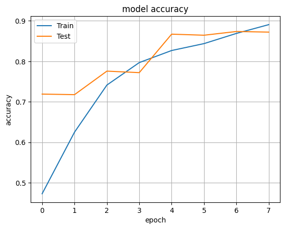

```python
plot_graph(history[8])
```

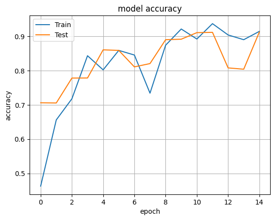

```python
plot_graph(history[15])
```

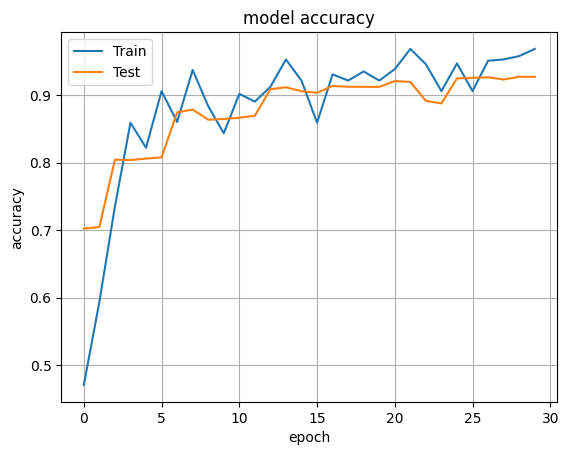

```python
plot_graph(history[30])
```

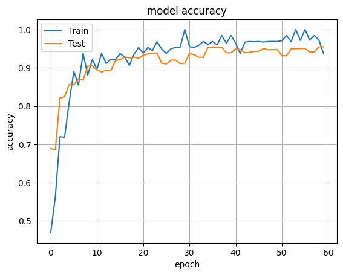

```python
plot_graph(history[60])
```

## Erkenntnisse

- Durch die Erhöhung der Epochenanzahl ist eine deutliche Steigerung der Accuracy erkennbar
- Die Trainings- und Test-Kurven nähren sich einem Schwellwert der nicht überschritten wird
- Ab einer gewissen Epochenanzahl (ca.45) ist nur noch eine sehr geringe Änderung in der Accuracy erkennbar